# Multivariate Regression Examples

Examples of regression models with more than one variable

### Swiss data

Scatterplots showing pairwise relationships between the variables.

All of the variables, except for fertility, are proportions of population.

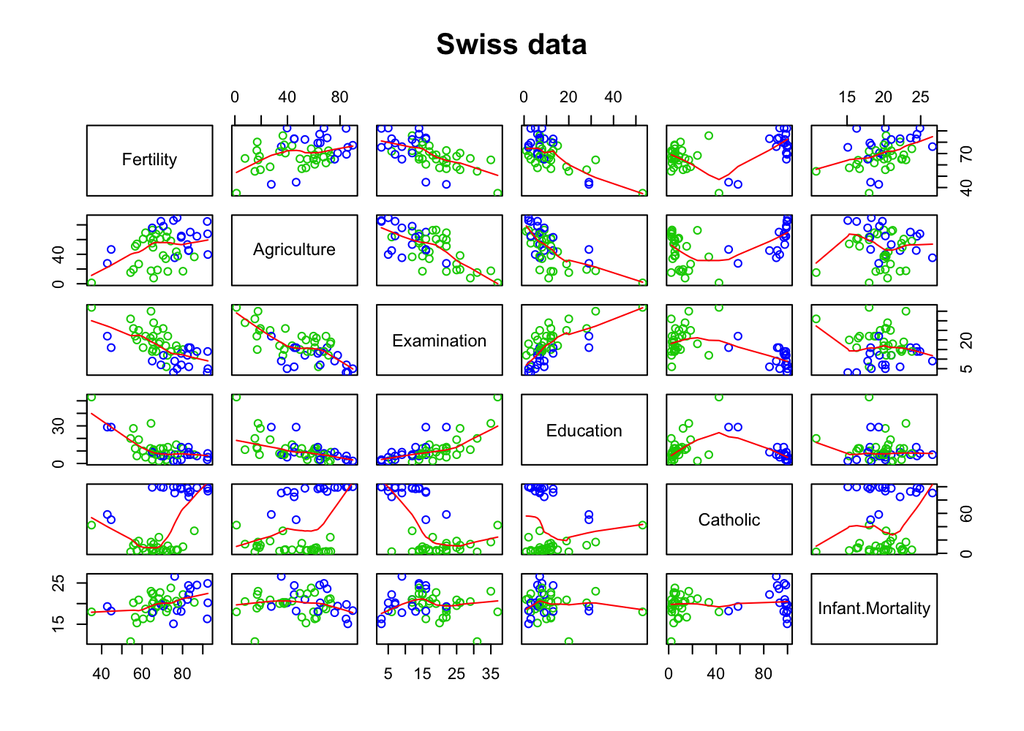

```r
all <- lm(Fertility ~ ., swiss)
summary(all)
```

```
Call:
lm(formula = Fertility ~ ., data = swiss)

Residuals:
     Min       1Q   Median       3Q      Max
-15.2743  -5.2617   0.5032   4.1198  15.3213

Coefficients:
                 Estimate Std. Error t value Pr(>|t|)
(Intercept)      66.91518   10.70604   6.250 1.91e-07 ***
Agriculture      -0.17211    0.07030  -2.448  0.01873 *
Examination      -0.25801    0.25388  -1.016  0.31546
Education        -0.87094    0.18303  -4.758 2.43e-05 ***
Catholic          0.10412    0.03526   2.953  0.00519 **
Infant.Mortality  1.07705    0.38172   2.822  0.00734 **
---
Signif. codes:  0 '***' 0.001 '**' 0.01 '*' 0.05 '.' 0.1 ' ' 1

Residual standard error: 7.165 on 41 degrees of freedom
Multiple R-squared:  0.7067,    Adjusted R-squared:  0.671
F-statistic: 19.76 on 5 and 41 DF,  p-value: 5.594e-10
```

For every 1% increase in percent of males involved in agriculture as an occupation we expect a .17 decrease in fertility, holding all the other variables constant; for every 1% increase in Catholicism, we expect a .10 increase in fertility, holding all other variables constant.

The `*` at the far end of the row indicates that the influence of Agriculture on Fertility is significant.

```r
summary(lm(Fertility ~ Agriculture, swiss))
```

```
Call:
lm(formula = Fertility ~ Agriculture, data = swiss)

Residuals:
     Min       1Q   Median       3Q      Max
-25.5374  -7.8685  -0.6362   9.0464  24.4858

Coefficients:
            Estimate Std. Error t value Pr(>|t|)
(Intercept) 60.30438    4.25126  14.185   <2e-16 ***
Agriculture  0.19420    0.07671   2.532   0.0149 *
---
Signif. codes:  0 '***' 0.001 '**' 0.01 '*' 0.05 '.' 0.1 ' ' 1

Residual standard error: 11.82 on 45 degrees of freedom
Multiple R-squared:  0.1247,    Adjusted R-squared:  0.1052
F-statistic: 6.409 on 1 and 45 DF,  p-value: 0.01492
```

The sign of the Agriculture coefficient changed form negative (when all the variables were included in the model) to positive (only using Agriculture).

The presence of the other factorsffects the influence of Agriculture has on fertility.

Education and performance on Examination are expected to be correlated

```r
cor(swiss$Education, swiss$Examination)
```

```
[1] 0.6984153
```

```r
cor(swiss$Education, swiss$Agriculture)
```

```
[1] -0.6395225
```

Negative correlation. This negative correlation might be affecting Agriculture’s influence on Fertility.

Generate 5 lm.

Each model has one more independent variable than the preceding model, so the first has just one independent variable, Agriculture, and the last has all 5.

```r
makelms()
```

```
Agriculture Agriculture Agriculture Agriculture Agriculture
  0.1942017   0.1095281  -0.2030377  -0.2206455  -0.1721140
```

The addition of `Education` changes the sign of the Agriculture’s coefficient from positive to negative

Adding a variable that will provide no new linear info to the model.

Adding this new variable will not change the model.

```r
# new variable
ec <- swiss$Examination + swiss$Catholic

# new model
efit <- lm(Fertility ~ . + ec, swiss)

# subtract efit coefficients from the frist model all
efit$coef - all$coef
```

```
     (Intercept)      Agriculture      Examination        Education         Catholic
               0                0                0                0                0
Infant.Mortality               ec
               0               NA
```

```r
all$coefficients-efit$coefficients
```

```
     (Intercept)      Agriculture      Examination        Education         Catholic
               0                0                0                0                0
Infant.Mortality               ec
               0               NA
```